# TCGA analysis

```r
library(dplyr)
library(ggplot2)
library(DT)
library(TCGAbiolinks)
```

## Workflow reference paper

Chinese CRC vs TCGA [Chinese CRC vs TCGA online](https://www.sciencedirect.com/science/article/pii/S0888754324000302?via%3Dihub)

```r
dir = "~/Desktop/git/template/TCGA/"
data = readRDS(paste0(dir,"data/data.rds"))
```

TCGA-LUAD  
Data Category: Simple Nucleotide Variation  
Data Type: Masked Somatic Mutation (WES 데이터를 포함)

194729 obs  
141 variables

## 분석 using maftools

```r
library(maftools)
```

### MAF 파일 로드

MAF (Mutation Annotation Format)

```r
maf <- read.maf(maf = data)
```

```
## -Validating
## -Silent variants: 47915
## -Summarizing
## --Possible FLAGS among top ten genes:
##   TTN
##   MUC16
##   USH2A
##   FLG
## -Processing clinical data
## --Missing clinical data
## -Finished in 7.740s elapsed (7.384s cpu)
```

### 기본적인 MAF 분석

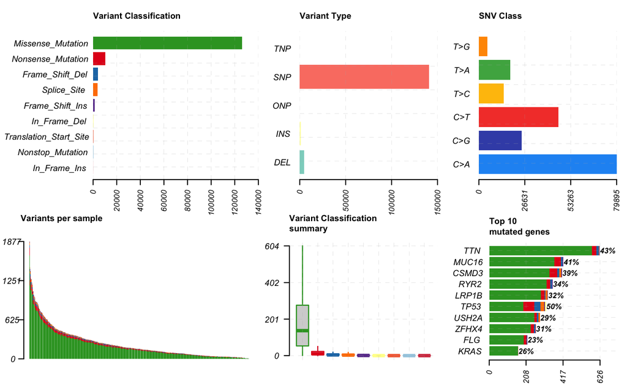

```r
plotmafSummary(maf = maf)
```

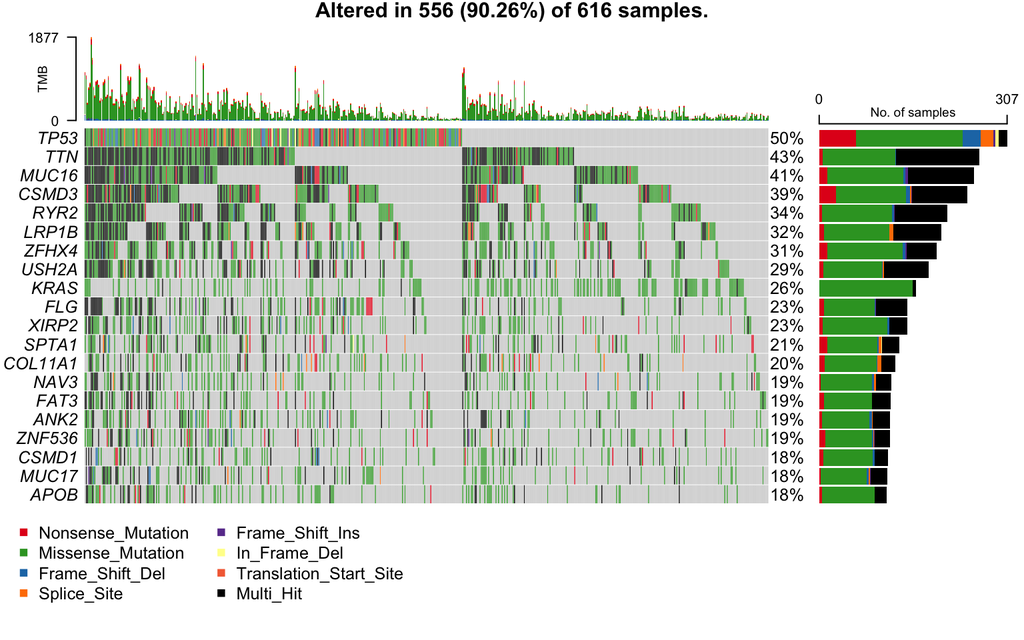

```r
oncoplot(maf = maf, top = 20)
```

### MAF 요약 정보

```r
maf
```

```
## An object of class  MAF
## Index: <ID>
##                         ID summary    Mean Median
##                     <char>  <char>   <num>  <num>
##  1:             NCBI_Build  GRCh38      NA     NA
##  2:                 Center      BI      NA     NA
##  3:                Samples     616      NA     NA
##  4:                 nGenes   16642      NA     NA
##  5:        Frame_Shift_Del    4256   6.909    4.0
##  6:        Frame_Shift_Ins    1290   2.094    1.0
##  7:           In_Frame_Del     406   0.659    0.0
##  8:           In_Frame_Ins      49   0.080    0.0
##  9:      Missense_Mutation  126254 204.958  137.5
## 10:      Nonsense_Mutation   10454  16.971   10.0
## 11:       Nonstop_Mutation     175   0.284    0.0
## 12:            Splice_Site    3719   6.037    3.0
## 13: Translation_Start_Site     211   0.343    0.0
## 14:                  total  146814 238.334  158.5
```

```r
maf@variants.per.sample
```

```
##              Tumor_Sample_Barcode Variants
##                            <fctr>    <int>
##   1: TCGA-17-Z031-01A-01W-0746-08     1877
##   2: TCGA-55-8506-01A-11D-2393-08     1458
##   3: TCGA-05-4382-01A-01D-1931-08     1404
##   4: TCGA-78-7155-01A-11D-2036-08     1285
##   5: TCGA-55-7994-01A-11D-2184-08     1279
##  ---
## 612: TCGA-L4-A4E6-01A-11D-A24D-08        4
## 613: TCGA-17-Z054-01A-01W-0747-08        4
## 614: TCGA-17-Z019-01A-01W-0746-08        2
## 615: TCGA-55-8513-01A-11D-2393-08        1
## 616: TCGA-49-AARR-01A-11D-A410-08        1
```

```r
maf@variant.type.summary
```

```
##              Tumor_Sample_Barcode   DEL   INS   ONP   SNP   TNP total
##                            <fctr> <int> <int> <int> <int> <int> <num>
##   1: TCGA-17-Z031-01A-01W-0746-08    43    10     0  1824     0  1877
##   2: TCGA-55-8506-01A-11D-2393-08   122    37     0  1299     0  1458
##   3: TCGA-05-4382-01A-01D-1931-08    23     9     0  1372     0  1404
##   4: TCGA-78-7155-01A-11D-2036-08    58     4     0  1222     1  1285
##   5: TCGA-55-7994-01A-11D-2184-08    52    14     0  1213     0  1279
##  ---
## 612: TCGA-17-Z054-01A-01W-0747-08     0     0     0     4     0     4
## 613: TCGA-L4-A4E6-01A-11D-A24D-08     0     0     0     4     0     4
## 614: TCGA-17-Z019-01A-01W-0746-08     0     1     0     1     0     2
## 615: TCGA-49-AARR-01A-11D-A410-08     0     0     0     1     0     1
## 616: TCGA-55-8513-01A-11D-2393-08     0     0     0     1     0     1
```

```r
maf@variant.classification.summary
```

```
##              Tumor_Sample_Barcode Frame_Shift_Del Frame_Shift_Ins In_Frame_Del
##                            <fctr>           <int>           <int>        <int>
##   1: TCGA-17-Z031-01A-01W-0746-08              38              10            1
##   2: TCGA-55-8506-01A-11D-2393-08             109              37           12
##   3: TCGA-05-4382-01A-01D-1931-08              22               9            1
##   4: TCGA-78-7155-01A-11D-2036-08              49               3            7
##   5: TCGA-55-7994-01A-11D-2184-08              49              13            2
##  ---
## 612: TCGA-17-Z054-01A-01W-0747-08               0               0            0
## 613: TCGA-L4-A4E6-01A-11D-A24D-08               0               0            0
## 614: TCGA-17-Z019-01A-01W-0746-08               0               1            0
## 615: TCGA-49-AARR-01A-11D-A410-08               0               0            0
## 616: TCGA-55-8513-01A-11D-2393-08               0               0            0
##      In_Frame_Ins Missense_Mutation Nonsense_Mutation Nonstop_Mutation
##             <int>             <int>             <int>            <int>
```

[output cut: 24 more lines]

```r
maf@gene.summary
```

```
##        Hugo_Symbol Frame_Shift_Del Frame_Shift_Ins In_Frame_Del In_Frame_Ins
##             <char>           <int>           <int>        <int>        <int>
##     1:        TP53              36               4            6            0
##     2:         TTN              15               3            0            0
##     3:       MUC16               8               6            0            0
##     4:       CSMD3              12               3            0            0
##     5:        RYR2              10               3            0            0
##    ---
## 16638:      ZNHIT2               0               0            0            0
## 16639:       ZNRD2               0               0            0            0
## 16640:       ZPBP2               0               0            0            0
## 16641:     ZSCAN26               0               0            0            0
## 16642:     ZSCAN32               0               0            0            0
##        Missense_Mutation Nonsense_Mutation Nonstop_Mutation Splice_Site
##                    <int>             <int>            <int>       <int>
```

[output cut: 24 more lines]

```r
maf@maf.silent
```

```
## Indices: <Variant_Type>, <Hugo_Symbol>
##            X1 Hugo_Symbol Entrez_Gene_Id Center NCBI_Build Chromosome
##        <fctr>      <char>          <int> <char>     <char>     <char>
##     1:      1     ELAPOR1          57535     BI     GRCh38       chr1
##     2:      1      YY1AP1          55249     BI     GRCh38       chr1
##     3:      1       FCRL3         115352     BI     GRCh38       chr1
##     4:      1       HDAC4           9759     BI     GRCh38       chr2
##     5:      1        SNTN         132203     BI     GRCh38       chr3
##    ---
## 47911:    618        PMM1           5372     BI     GRCh38      chr22
## 47912:    618     MAGEB10         139422     BI     GRCh38       chrX
## 47913:    618       EFHC2          80258     BI     GRCh38       chrX
## 47914:    618     PCDH11X          27328     BI     GRCh38       chrX
## 47915:    618       TENM1          10178     BI     GRCh38       chrX
##        Start_Position End_Position Strand Variant_Classification Variant_Type
```

[output cut: 493 more lines]

```r
# sample barcode
maf@clinical.data
```

```
##              Tumor_Sample_Barcode
##                            <char>
##   1: TCGA-05-4244-01A-01D-1105-08
##   2: TCGA-05-4249-01A-01D-1105-08
##   3: TCGA-05-4250-01A-01D-1105-08
##   4: TCGA-05-4382-01A-01D-1931-08
##   5: TCGA-05-4384-01A-01D-1753-08
##  ---
## 612: TCGA-NJ-A55O-01A-11D-A25L-08
## 613: TCGA-NJ-A55R-01A-11D-A25L-08
## 614: TCGA-NJ-A7XG-01A-12D-A397-08
## 615: TCGA-O1-A52J-01A-11D-A25L-08
## 616: TCGA-S2-AA1A-01A-12D-A397-08
```

```r
getSampleSummary(maf)
```

```
##              Tumor_Sample_Barcode Frame_Shift_Del Frame_Shift_Ins In_Frame_Del
##                            <fctr>           <int>           <int>        <int>
##   1: TCGA-17-Z031-01A-01W-0746-08              38              10            1
##   2: TCGA-55-8506-01A-11D-2393-08             109              37           12
##   3: TCGA-05-4382-01A-01D-1931-08              22               9            1
##   4: TCGA-78-7155-01A-11D-2036-08              49               3            7
##   5: TCGA-55-7994-01A-11D-2184-08              49              13            2
##  ---
## 612: TCGA-17-Z054-01A-01W-0747-08               0               0            0
## 613: TCGA-L4-A4E6-01A-11D-A24D-08               0               0            0
## 614: TCGA-17-Z019-01A-01W-0746-08               0               1            0
## 615: TCGA-49-AARR-01A-11D-A410-08               0               0            0
## 616: TCGA-55-8513-01A-11D-2393-08               0               0            0
##      In_Frame_Ins Missense_Mutation Nonsense_Mutation Nonstop_Mutation
##             <int>             <int>             <int>            <int>
```

[output cut: 24 more lines]

```r
getGeneSummary(maf)
```

```
##        Hugo_Symbol Frame_Shift_Del Frame_Shift_Ins In_Frame_Del In_Frame_Ins
##             <char>           <int>           <int>        <int>        <int>
##     1:        TP53              36               4            6            0
##     2:         TTN              15               3            0            0
##     3:       MUC16               8               6            0            0
##     4:       CSMD3              12               3            0            0
##     5:        RYR2              10               3            0            0
##    ---
## 16638:      ZNHIT2               0               0            0            0
## 16639:       ZNRD2               0               0            0            0
## 16640:       ZPBP2               0               0            0            0
## 16641:     ZSCAN26               0               0            0            0
## 16642:     ZSCAN32               0               0            0            0
##        Missense_Mutation Nonsense_Mutation Nonstop_Mutation Splice_Site
##                    <int>             <int>            <int>       <int>
```

[output cut: 24 more lines]

### Oncoprint

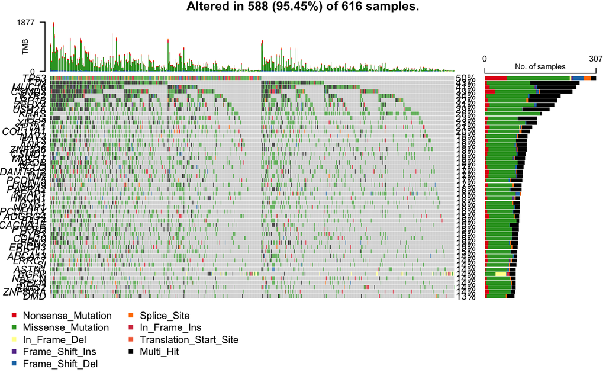

```r
oncoplot(maf = maf, top = 50)
```

### 돌연변이 요약

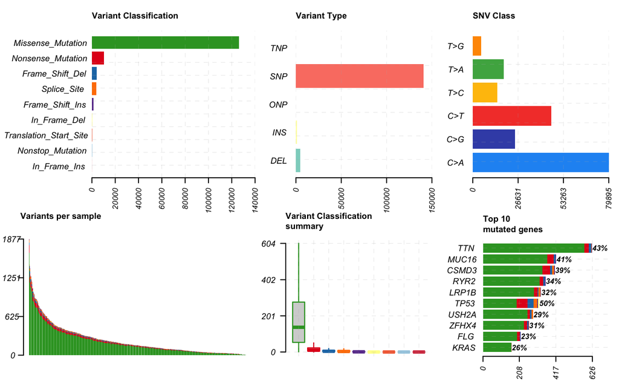

```r
plotmafSummary(maf = maf)
```

### 특정 유전자의 lollipop plot

```
##      HGNC    refseq.ID   protein.ID aa.length
##    <char>       <char>       <char>     <num>
## 1:   TP53    NM_000546    NP_000537       393
## 2:   TP53 NM_001126112 NP_001119584       393
## 3:   TP53 NM_001126113 NP_001119585       346
## 4:   TP53 NM_001126114 NP_001119586       341
## 5:   TP53 NM_001126115 NP_001119587       261
## 6:   TP53 NM_001126116 NP_001119588       209
## 7:   TP53 NM_001126117 NP_001119589       214
## 8:   TP53 NM_001126118 NP_001119590       354
```

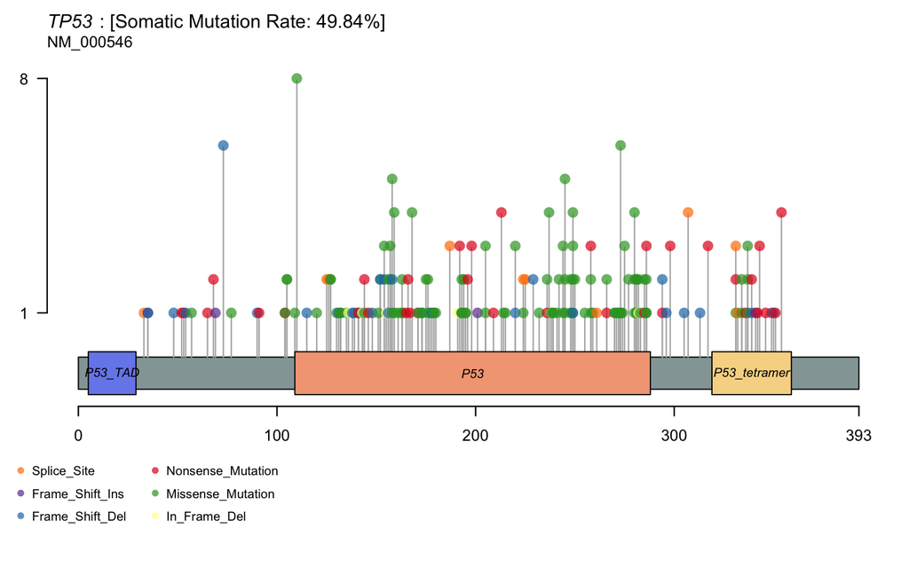

```r
lollipopPlot(maf = maf, gene = "TP53")
```

```r
# 두 집단 간 돌연변이 비교
maf1 <- subsetMaf(maf, Tumor_Sample_Barcode %in% group1_samples)
maf2 <- subsetMaf(maf, Tumor_Sample_Barcode %in% group2_samples)
mafCompare(maf1, maf2)
```

### 공변이 및 상호 배제 패턴 분석

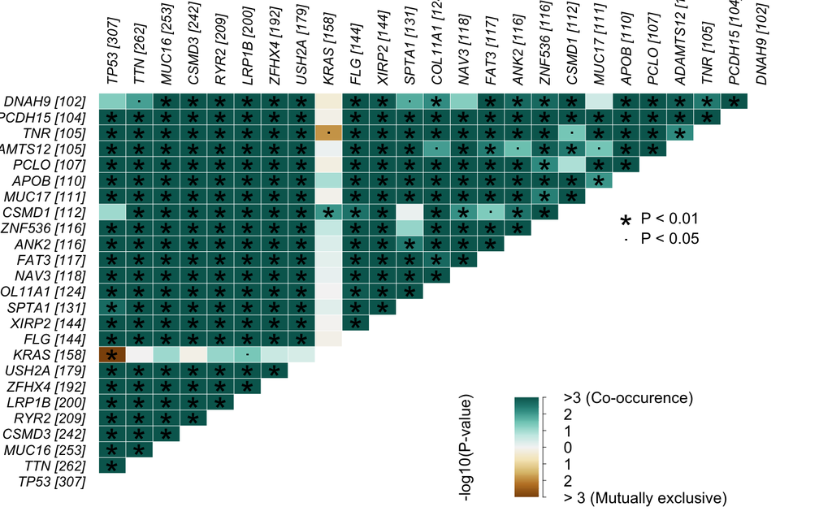

```
##         gene1  gene2       pValue oddsRatio    00    11    01    10
##        <char> <char>        <num>     <num> <int> <int> <num> <num>
##   1:    LRP1B  MUC16 1.122434e-18 4.8823496   296   133   120    67
##   2:    CSMD3    TTN 3.465805e-18 4.4337881   267   155   107    87
##   3:    USH2A  CSMD3 1.326806e-17 4.8686787   313   118   124    61
##   4:      TTN  MUC16 6.281772e-17 4.1314320   259   158    95   104
##   5:     APOB  MUC16 1.693377e-16 6.4215723   337    84   169    26
##  ---
## 296: ADAMTS12   KRAS 8.066362e-01 1.0656212   381    28   130    77
## 297:     KRAS  MUC17 8.105044e-01 0.9177853   374    27    84   131
## 298:    XIRP2   KRAS 9.133019e-01 0.9563497   350    36   122   108
## 299:      TTN   KRAS 1.000000e+00 0.9930231   263    67    91   195
## 300:  COL11A1   KRAS 1.000000e+00 1.0103395   366    32   126    92
##              pAdj              Event           pair event_ratio
##             <num>             <char>         <char>      <char>
##   1: 2.598226e-17       Co_Occurence   LRP1B, MUC16     133/187
##   2: 7.469406e-17       Co_Occurence     CSMD3, TTN     155/194
##   3: 2.675013e-16       Co_Occurence   CSMD3, USH2A     118/185
##   4: 1.189730e-15       Co_Occurence     MUC16, TTN     158/199
##   5: 3.023888e-15       Co_Occurence    APOB, MUC16      84/195
##  ---
## 296: 8.170950e-01       Co_Occurence ADAMTS12, KRAS      28/207
## 297: 8.183607e-01 Mutually_Exclusive    KRAS, MUC17      27/215
## 298: 9.191847e-01 Mutually_Exclusive    KRAS, XIRP2      36/230
## 299: 1.000000e+00 Mutually_Exclusive      KRAS, TTN      67/286
## 300: 1.000000e+00       Co_Occurence  COL11A1, KRAS      32/218
```

```r
somaticInteractions(maf = maf)
```

## 참고 자료

- [maftools 패키지 문서](https://bioconductor.org/packages/release/bioc/html/maftools.html)
- [maftools GitHub](https://github.com/PoisonAlien/maftools)
- [maftools vignette](https://bioconductor.org/packages/release/bioc/vignettes/maftools/inst/doc/maftools.html)

## 주요 기능

1. **MAF 파일 로드 및 요약**:
   - `read.maf()`: MAF 파일을 로드합니다.
   - `getSampleSummary()`: 샘플별 돌연변이 요약 정보를 제공합니다.
   - `getGeneSummary()`: 유전자별 돌연변이 요약 정보를 제공합니다.
2. **시각화 도구**:
   - `oncoplot()`: Oncoprint를 생성하여 유전자와 샘플 간의 돌연변이 패턴을 시각화합니다.
   - `plotmafSummary()`: 돌연변이 데이터의 요약 통계를 시각화합니다.
   - `lollipopPlot()`: 특정 유전자의 돌연변이 위치를 시각화합니다.
   - `rainfallPlot()`: 돌연변이의 크로모솜 내 분포를 시각화합니다.
3. **돌연변이 서브타입 분석**:
   - `mafCompare()`: 두 집단 간의 돌연변이 패턴을 비교합니다.
   - `somaticInteractions()`: 공변이 및 상호 배제 패턴을 분석합니다.
4. **기능적 영향 분석**:
   - `drugInteractions()`: 돌연변이와 약물 간의 상호 작용을 분석합니다.
   - `oncostrip()`: 암 관련 유전자의 변이 정보를 시각화합니다.

## Key Differences between TCGA-LUAD and TCGA-LUSC

| Characteristic | TCGA-LUAD (Lung Adenocarcinoma) | TCGA-LUSC (Lung Squamous Cell Carcinoma) |
| --- | --- | --- |
| **Location** | Peripheral lung, alveoli, and small airways | Central lung, large airways, and bronchi |
| **Cell Type** | Adenocarcinoma cells, mucus-secreting | Squamous cells, keratinization, and intercellular bridges |
| **Cause** | Can occur in both smokers and non-smokers; more common in non-smokers | Strongly associated with smoking |
| **Common Genetic Mutations** | EGFR, ALK, KRAS | TP53, CDKN2A, FGFR1 |